# Anàlisi de dissenys d’un factor

Antonio Miñarro (aminarro@ub.edu)

Setembre 2015

# Comparant grups o tractaments. Anàlisi de la variància (ANOVA)

- L’objectiu és estudiar si un únic factor amb $k$ nivells pot influir en una determinada variable resposta cuantitativa.
- Es una generalització del test t de Student per comparar si el valor de la mitjana poblacional de la variable resposta és diferent segons el nivell del factor (diferents poblacions independents)
- En terminologia de l’anàlisi de la variància anomenem

> – **factor** a la característica que separa els diferents grups

> – **nivell** a cadascun dels grups que conformen el factor

# Exemple 1. Comparació eficàcia de tres fàrmacs

- Volem comparar l’eficàcia de tres fàrmacs (tractaments)
- La **variable resposta** és la diferència enre els valors després i abans dels tractament d’una determinada variable bioquímica.

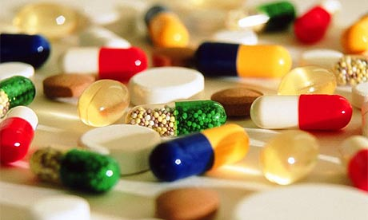

- Una mostra de 24 pacients **s’aleatoritza** totalment respecte al tractament.

Els resultats han estat els següents

$\begin{array}{c|c|c|c} Individu & Tract. 1 & Tract. 2 & Tract. 3 \\ \hline 1 & 4 & 7 & 9 \\ 2 & 2 & 6 & 12 \\ 3 & 6 & 5 & 6 \\ 4 & 6 & 7 & 11 \\ 5 & 5 & 6 & 10 \\ 6 & 6 & 4 & 11 \\ 7 & 2 & 7 & 9 \\ 8 & 6 & 5 & 10 \end{array}$

En aquest cas tenim **un factor** (el tractament) amb **tres nivells**.

**Provar si hi ha relació entre el tractament i la variable resposta**.

# Disseny completament aletoritzat

- Cada unitat experimental s’assigna, a l’atzar, a exactament una condició experimental o tractament (a cada nivell del factor)
- Com a conseqüència, el “factor” individu està jeràrquicament dins cada grup de tractament
- Diversos noms:

> – Disseny d’un sol factor: “una via” (one-way layout)

> – Disseny paral·lel per a un sol factor

> – Disseny completament aletoritzat

# Terminologia

- **Rèplica**: observacions de la variable resposta fetes sota les mateixes condicions experimentals.
- **Disseny balancejat**: situació experimental on es presenten el mateix nombre de rèpliques en cada grup/tractament .
- **Aleatorització**: un requisit bàsic. Cada unitat observada (cada rèplica) s’ha d’assignar aleatòriament a un tractament.
- **Factor fix**: si els nivells del factor analitzats són tots els rellevants per l’investigador.
- **Factor aleatori**: si els nivells del factor analitzats en l’experiment són una mostra d’un conjunt més gran de possibles nivells (tractaments) del factor.

# Anàlisi descriptiu de les dades amb R

```r
resp<-c(4,2,6,6,5,6,2,6,7,6,5,7,6,4,7,5,9,12,6,11,10,11,9,10)
tract<-factor(rep(1:3,each=8),labels=c('Farmac 1','Farmac 2','Farmac 3'))
farmacs<-data.frame(tract,resp)
summary(farmacs)
```

```
##       tract        resp
##  Farmac 1:8   Min.   : 2.00
##  Farmac 2:8   1st Qu.: 5.00
##  Farmac 3:8   Median : 6.00
##               Mean   : 6.75
##               3rd Qu.: 9.00
##               Max.   :12.00
```

```r
# descriptiva per grups
tapply(farmacs$resp,farmacs$tract,mean)
```

```
## Farmac 1 Farmac 2 Farmac 3
##    4.625    5.875    9.750
```

```r
#farmacs[1,2]<-NA
tapply(farmacs$resp,farmacs$tract,mean,na.rm=T)
```

```
## Farmac 1 Farmac 2 Farmac 3
##    4.625    5.875    9.750
```

```r
tapply(farmacs$resp,farmacs$tract,summary)
```

```
## $`Farmac 1`
##    Min. 1st Qu.  Median    Mean 3rd Qu.    Max.
##   2.000   3.500   5.500   4.625   6.000   6.000
##
## $`Farmac 2`
##    Min. 1st Qu.  Median    Mean 3rd Qu.    Max.
##   4.000   5.000   6.000   5.875   7.000   7.000
##
## $`Farmac 3`
##    Min. 1st Qu.  Median    Mean 3rd Qu.    Max.
##    6.00    9.00   10.00    9.75   11.00   12.00
```

```r
by(farmacs[,2],farmacs$tract,summary)
```

```
## farmacs$tract: Farmac 1
##    Min. 1st Qu.  Median    Mean 3rd Qu.    Max.
##   2.000   3.500   5.500   4.625   6.000   6.000
## --------------------------------------------------------
## farmacs$tract: Farmac 2
##    Min. 1st Qu.  Median    Mean 3rd Qu.    Max.
##   4.000   5.000   6.000   5.875   7.000   7.000
## --------------------------------------------------------
## farmacs$tract: Farmac 3
##    Min. 1st Qu.  Median    Mean 3rd Qu.    Max.
##    6.00    9.00   10.00    9.75   11.00   12.00
```

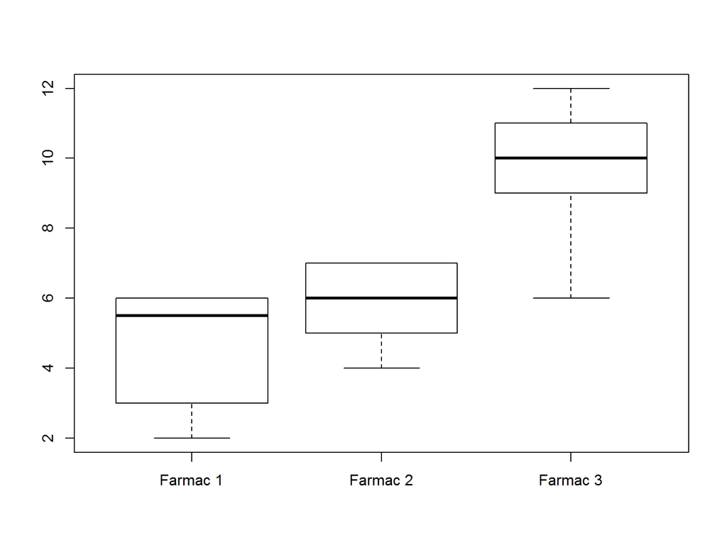

```r
boxplot(resp~tract,data=farmacs)
```

# Comparació de l’eficàcia dels tres fàrmacs

Volem determinar si els tres fàrmacs són igualment eficaços amb un nivell de significació $\alpha$ = 5 %.

Amb les eines que coneixem de primer, acceptant normalitat, i considerant 3 contrastos t de Student per parelles consecutius:

- fàrmac 1 contra fàrmac 2 ($\alpha$=5%)
- fàrmac 1 contra fàrmac 3 ($\alpha$=5%)
- fàrmac 2 contra fàrmac 3 ($\alpha$=5%)

aparentment es resol la qüestió plantejada. Però $\ldots$

aquesta forma directa de plantejar el problema comporta un error metodològic: el nivell de significació de las 3 proves juntes és superior a $\alpha$

si plantegem els dos tests següents

- fàrmac 1 contra fàrmac 2 ($\alpha$=5%)
- fàrmac 1 contra fàrmac 3 ($\alpha$=5%)

els contrastos son independents, essent l’error de tipus I global:

$\alpha_G$ = nivell de significació global = $1-(1-0.05)^2 = 0.0975$

si plantegem les 3 a l’hora, en no ser independents, només podem afirmar que $\alpha_G$ està entre 0.0975 i 0.15.

en general, quan més gran sigui el nº de grups, més gran serà $\alpha_G$ **¡acostant-se a 1!**. Cal doncs una tècnica alternativa.

# Model lineal del ANOVA un factor fix

Debem les tècniques del anàlisi de la variància al estadístic anglés [Ronald A. Fisher](https://en.wikipedia.org/wiki/Ronald_Fisher)

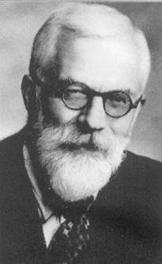

El model lineal assumit per les dades es:

$Y_{ij} = \mu + \alpha_i + \epsilon_{ij} \,\,\,\,\,\, i=1,...,a; \,\,\,\, j=1,...,r_i$

on

- $Y_{ij}$ és l’observació $j$ pel nivell $i$ del factor
- $\mu$ és una mitjana general
- $\alpha_i$ és un paràmetre del model que mesura l’efecte del nivell $i$ del factor
- $\epsilon_{ij}$ és l’error aleatori corresponent a l’observació $i,j$ i dels quals suposem que són independents i idènticament distribuits amb $E(\epsilon_{ij}) = 0$ i $Var(\epsilon_{ij})=\sigma^2$.
- També suposem que $\sum_{i=1}^a r_i \alpha_i = 0$. ($\sum_{i=1}^a \alpha_i = 0$ si el disseny és balancejat $(r_1=\ldots=r_a=n)$)

Com veurem serà necessari també assumir una distribució normal sobre els errors

$\epsilon_{ij} \sim N(0,\sigma)$

i per tant cada observació experimental

$Y_{ij} \sim N(\mu_i,\sigma)$

on $\mu_i = \mu + \alpha_i$.

# Contrast d’hipòtesis

L’Anova d’un factor contrasta la hipòtesi que no hi ha efecte dels tractaments. En forma paramètrica, les hipòtesis són:

$H_0: \alpha_1 = \alpha_2 = \cdots = \alpha_a = 0$ $H_1: \alpha_i \ne \alpha_{i'} \mbox{ per algun } i \ne i'$

Si rebutgem la hipòtesi nul·la, el test només indica que existeix una diferència global en els grups, però no concretament entre quins d’ells.

Una forma equivalent d’expressar la hipòtesi nul·la és mitjançant les mitjanes poblacionals de cada grup:

$H_0: \mu_1 = \mu_2 = \cdots = \mu_a$

# Estimacions dels paràmetres del model

- Definicions

> – $N=r_1+r_2+\cdots+r_a$

> – $Y_{i.} = \sum_{j=1}^{r_i} Y_{ij}$

> – $Y_{..} = \sum_{i=1}^{a} Y_{i.}=\sum_{i=1}^{a} \sum_{j=1}^{r_i} Y_{ij}$

> – $\bar{Y_{i.}}= \frac{Y_{i.}}{r_i}$

> – $\bar{Y_{..}}= \frac{Y_{..}}{N}$
- Estimadors puntuals dels paràmetres del model

> – $\hat{\mu} = \bar{Y_{..}}$

> – $\hat{\mu_i} = \bar{Y_{i.}}$

**Nota**: en cas d’un disseny balancejat $(r_1=\ldots=r_a=n)$ llavors $N = n \cdot a$.

# Descomposició de la variabilitat

La idea de Fisher va ser **descomposar la variabilitat total** de les dades en una part deguda a la **variabilitat entre tractaments** i una part deguda a la **variabilitat dintre dels tractaments**.

Posteriorment decidim si els tractaments són significatius **comparant aquestes dues darreres variabilitats**.

Es per això que tot i que estem contrastant mitjanes poblacionals la tècnica s’anomena **anàlisi de la variància**.

$\begin{eqnarray*} SS_T = & \sum_{i=1}^{a} \sum_{j=1}^{r_i} (Y_{ij}-\bar{Y_{..}} )^2 = \\ & = &\sum_{i=1}^{a} r_i (\bar{Y_{i.}}-\bar{Y_{..}} )^2 + \sum_{i=1}^{a} \sum_{j=1}^{r_i} (Y_{ij}-\bar{Y_{i.}} )^2 = \\ & = & SS_A + SS_E \end{eqnarray*}$

on

- $SS_T$ recull la variabilitat total de les dades,
- $SS_A$ recull la variabilitat entre tractaments i
- $SS_E$ recull la variabilitat dintre dels tractaments

# Descomposició de la variabilitat en les dades del exemple

```r
SST<-sum((resp-mean(resp))^2)
aux<-tapply(farmacs$resp,farmacs$tract,mean)
SSA<-8*sum((aux-mean(resp))^2)
aux2<-rep(aux,each=8)
SSE<-sum((resp-aux2)^2)
c(SST,SSA,SSE)
```

```
## [1] 168.50 114.25  54.25
```

Com podem arribar a decidir si la variabilitat entre tractaments és prou important com per dir que l’efecte dels tractaments és significatiu?

# Esperances dels quadrats mitjans

Si anomenem $MS_E = \frac{SS_E}{N-a}$ (quadrats mitjans de l’error) pot demostrar-se que $E(MS_E) = \sigma^2$ sempre.

Per una altra banda si anomenem $MS_A = \frac{SS_A}{a-1}$ (quadrats mitjans entre tractaments) pot demostrar-se que $E(MS_A) = \sigma^2 + \frac{\sum_{i=1}^a r_i \alpha_i^2}{a-1}$.

Per tant i si la hipòtesi nul·la es certa ($H_0: \alpha_1 = \alpha_2 = \cdots = \alpha_a = 0) \Rightarrow E(MS_A)=E(MS_E)=\sigma^2$ i per tant si plantegem

$F = \frac{MS_A}{MS_E} \approx 1$

En canvi si $H_0$ és falsa la tendència ha de ser que $F > 1$.

$F = \frac{MS_A}{MS_E} = \frac{\frac{SS_A}{a-1}}{\frac{SS_E}{N-a}}$

- Si $H_0$ és certa , $F$ tendirà a ser propera a 1.
- Si $H_0$ és falsa , $F$ tendirà a ser més gran que 1.

Per tant un criteri raonable per decidir consisteix en rebutjar $H_0$ si $F$ és prou gran

Si $F \ge c_\alpha \Rightarrow$ rebutgem $H_0$, on $c_\alpha$ és triat de forma que $P_{H_0} (F \ge c_\alpha) = \alpha$.

Per trobar $c_\alpha$ pot demostrar-se que sota la hipòtesi de errors normals i homocedàstics

$\epsilon_{ij} \sim N(0,\sigma)$

$MS_A$ i $MS_E$ segueixen una distribució $\chi^2$ amb $a-1$ i $N-a$ graus de llibertat respectivament i són independents, i com a conseqüència

$F = \frac{MS_A}{MS_E} = \frac{\frac{SS_A}{a-1}}{\frac{SS_E}{N-a}} \sim F(a-1,N-a)$

on $F(a-1,N-a)$ és una distribució $F$ de Fisher amb $a-1$ graus de llibertat en el numerador i $N-a$ graus de llibertat en el denominador.

# Taula de l’Anàlisi de la variància (ANOVA)

| Font de variació | Suma de quadrats | Graus de llibertat | Quadrats mitjans | Estadístic F |
| --- | --- | --- | --- | --- |
| Entre tractaments | $SS_A$ | $a-1$ | $MS_A = \frac{SS_A}{a-1}$ | $F = \frac{MS_A}{MS_E}$ |
| Error (dintre nivells) | $SS_E$ | $N-a$ | $MS_E = \frac{SS_E}{N-a}$ |  |
| Total | $SS_T$ | $N-1$ |  |  |

- Criteri de decisió

> – Calcular el valor del estadístic $F$ de la taula a partir de les dades.

> – Determinar el valor crític $F_{\alpha} (a-1,N-a)$ per a una distribució $F$ de Fisher amb $a-1$ graus de llibertat en el numerador i $N-a$ graus de llibertat en el denominador d’acord amb $\alpha$.

> – Si $F \ge F_{\alpha} (a-1,N-a)$ rebutjarem $H_0$ o, equivalentment, si el p-valor és prou petit i obtenim el resultat amb un software estadístic.

# Taula de l’Anàlisi de la variància (ANOVA) (exemple)

| Font de variació | Suma de quadrats | Graus de llibertat | Quadrats mitjans | Estadístic F |
| --- | --- | --- | --- | --- |
| Entre tractaments | 114.25 | 2 | 57.125 | $F =$ 22.113 |
| Error (dintre nivells) | 54.25 | 21 | 2.5833 |  |
| Total | 168.50 | 23 |  |  |

Valor crític $F_{0.05} (2,21) = 3.4668$ .

La decisió és **rebutjar la hipòtesi nul·la** i concloure que **no tots els tractaments són equivalents** per la variable resposta.

# Resolució amb R

```r
# anova
farmacs.aov<-aov(resp~tract,farmacs)
anova(farmacs.aov)
```

```
## Analysis of Variance Table
##
## Response: resp
##           Df Sum Sq Mean Sq F value   Pr(>F)
## tract      2 114.25  57.125  22.113 6.79e-06 ***
## Residuals 21  54.25   2.583
## ---
## Signif. codes:  0 '***' 0.001 '**' 0.01 '*' 0.05 '.' 0.1 ' ' 1
```

```r
# taules de coefficients i mitjanes
taula<-model.tables(farmacs.aov,type='mean')
taula
```

```
## Tables of means
## Grand mean
##
## 6.75
##
##  tract
## tract
## Farmac 1 Farmac 2 Farmac 3
##    4.625    5.875    9.750
```

- Estimació dels paràmetres del model

> – $\hat{\mu} =$ 6.75

> – $\hat{\sigma^2}$ = 2.5833333 $\Rightarrow \hat{\sigma}$ = 1.6072751

# Intervals de confiança pels paràmetres del model

A partir del fet que

$\hat{\mu_i} = \bar{Y_{i.}} \sim N(\mu_i,\frac{\sigma}{\sqrt{r_i}}) \Rightarrow \frac{ \bar{Y_{i.}}-\mu_i}{\frac{\sigma}{\sqrt{n}}} \sim N(0,1)$

si substituïm $\sigma^2$ pel seu estimador $MS_E$:

$\frac{ \bar{Y_{i.}}-\mu_i}{\sqrt{\frac{MS_E}{r_i}}} \sim t_{N-a},$

tenim com a interval de confiança al $(1-\alpha) \cdot 100 \%$ per $\mu_i$:

$\bar{Y_{i.}} \pm t_{(\alpha/2,N-a)} \cdot \sqrt{\frac{MS_E}{r_i}}$

- En el nostre exemple $N-a = 21$ i amb una confiança del 95 % $t_{(0.025,21)}=2.080$, resultant els següents intervals:

– Per $\mu_1$: 4.625 $\pm$ 2.080 $\sqrt{\frac{2.583}{8}} =$ (3.4431005 , 5.8068995)

– Per $\mu_2$: 5.875 $\pm$ 2.080 $\sqrt{\frac{2.583}{8}} =$ (4.6931005 , 7.0568995)

– Per $\mu_3$: 9.75 $\pm$ 2.080 $\sqrt{\frac{2.583}{8}} =$ (8.5681005 , 10.9318995)

### Amb R i les dades del exemple

```r
confint(aov(resp~tract-1,farmacs))
```

```
##                  2.5 %    97.5 %
## tractFarmac 1 3.443244  5.806756
## tractFarmac 2 4.693244  7.056756
## tractFarmac 3 8.568244 10.931756
```

# Verificació de les premisses del ANOVA

Per tal de poder aplicar la teoria dels models linals, es requereixen tres requisits:

- **Homocedasticitat**: igualtat de les variàncies en tots els grups
- **Normalitat** dels residus
- **Independència** de les observacions

El test $F$ del ANOVA pot arribar a ser poc creïble si es fa un estudi amb mides mostrals diferents combinades amb dades no normals de diferent variància.

# Verificació de la homocedasticitat

Es potser la premissa a verificar amb més cura.

En experiments simulats s’ha vist que amb 4 grups de mida 11 i amb una ratio 16:1 de la variància més gran a la més petita la probabilitat d’error de tipus I real era de 0.109 en lloc del nominal 0.05; i pot arribar a 0.275 si les mides dels grups son: 4,10, 16 i 40.

Un disseny balancejat pot esmorteir en part l’impacte que té sobre el nivell de significació real una desviació moderada de la homocedasticitat.

Les proves de Bartlett i Levene són algunes de les més populars per verificar la homocedasticitat.

En elles la hipòtesi nul·la és la homogeneitat de variàncies.

$H_0: \sigma_1^2 = \sigma_2^2 = \cdots = \sigma_a^2 = 0$ $H_1: \sigma_i^2 \ne \sigma_{i'}^2 \mbox{ per algun } i \ne i'$

El test de Levene és menys sensible a desviacions de la normalitat.

- [Test de Bartlett (Wikipedia)](https://en.wikipedia.org/wiki/Bartlett%27s_test)
- [Test de Levene (Wikipedia)](https://en.wikipedia.org/wiki/Levene%27s_test)

### Test de Bartlett amb R i dades del exemple

```r
bartlett.test(resp~tract,farmacs)
```

```
##
##  Bartlett test of homogeneity of variances
##
## data:  resp by tract
## Bartlett's K-squared = 1.7073, df = 2, p-value = 0.4259
```

```r
library(car)
leveneTest(resp~tract,farmacs)
```

```
## Levene's Test for Homogeneity of Variance (center = median)
##       Df F value Pr(>F)
## group  2  0.4174 0.6641
##       21
```

### Anàlisi gràfic

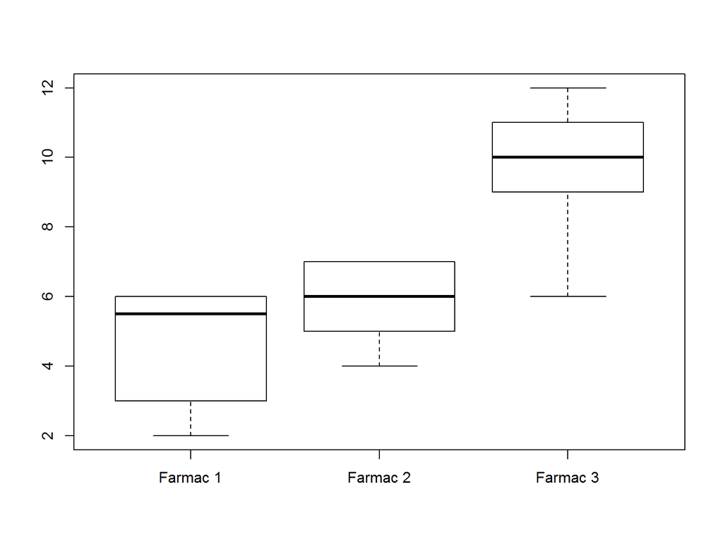

```r
boxplot(resp~tract,data=farmacs)
```

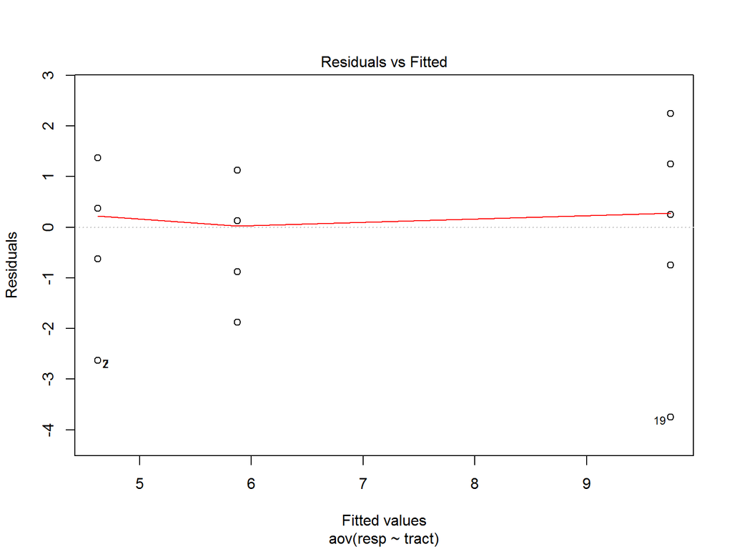

```r
plot(farmacs.aov,which=1)
```

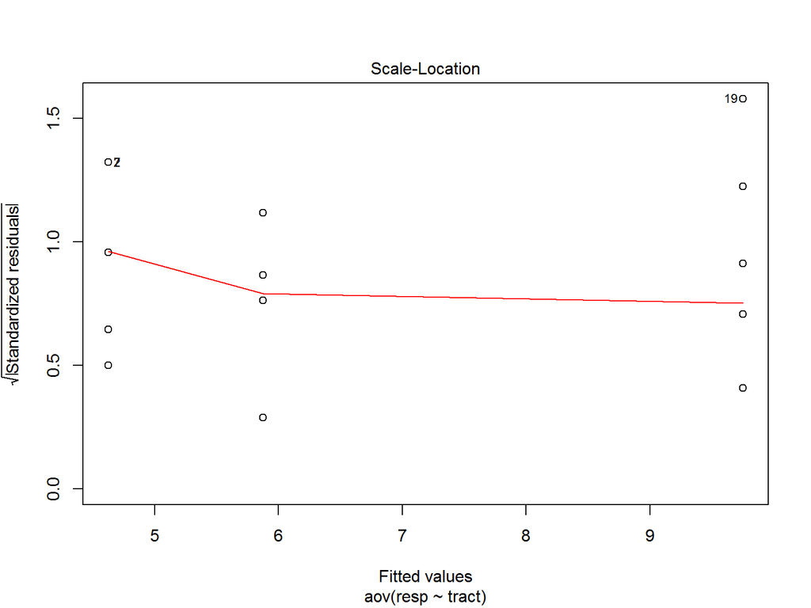

```r
plot(farmacs.aov,which=3)
```

### Que fer en cas de heterocedasticitat

Si les variàncies són diferents com a possibles solucions tenim la transformació de la variable, si la heterogeneïtat es deguda a una distribució esbiaixada de la variable resposta o alternativament ajustant models lineals generalitzats que permeten ajustar diferents distribucions als errors del model.

# Verificació de la normalitat dels residus

Por fer-se per mitjans gràfics: QQ-plots o histogrames

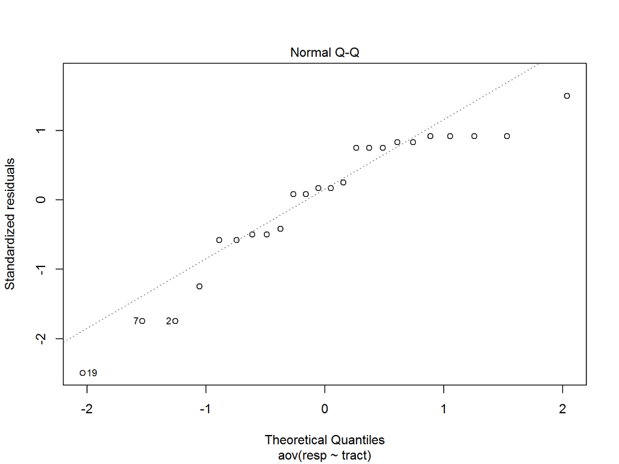

```r
plot(farmacs.aov,which=2)
```

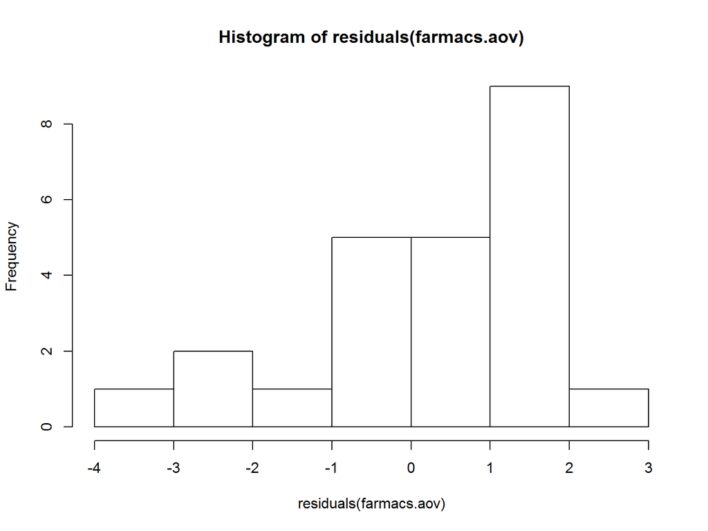

```r
hist(residuals(farmacs.aov))
```

o també pot comprovar-se a través de diferents tests de normalitat: Shapiro-Wilks, Kolmogorov-Smirnov-Lilliefors,…

Amb mostres petites és més informatiu utilitzar les tècniques gràfiques.

El test $F$ és robust front a desviacions moderades de la normalitat si els residus tenen una distribució simètrica i sobre tot en el cas de mides mostrals i variàncies similars.

```r
shapiro.test(farmacs.aov$residuals)
```

```
##
##  Shapiro-Wilk normality test
##
## data:  farmacs.aov$residuals
## W = 0.9065, p-value = 0.02968
```

### Que fer en cas de no normalitat

Existeixen alternatives no paramètriques en cas de una accentuada no normalitat de les dades.

# Verificació de la independència de les observacions

La millor forma de garantir la independència és amb un model adient de mostratge i amb l’aleatorització prèvia a l’assignació dels tractaments i, si s’escau, en el moment de la lectura de la variable resposta.

# Comparacions múltiples

- **Un cop que l’ANOVA ha estat significatiu** l’objectiu és decidir quins grups concrets presenten diferències.

– No és raonable fer comparacions dos a dos utilitzant la prova t de Student habitual per les consideracions fetes al principi del tema on veiem que es descontrolava la probabilitat de l’error de tipus I. Hem d’assegurar un nivell de significació global $\le \alpha$.

- Els tests de comparacions múltiples es diferencien entre sí per la forma en que garanteixen el nivell de significació global $\alpha_G$ (possible error de tipus I considerant **totes les proves per parelles** en conjunt).

– la garantia sobre $\alpha_G$ es tradueix de forma diferent segons la tècnica escollida en el nivell de significació individual de cada prova per parelles.

### Contrastos conservadors i lliberals

- **Test conservador**: per tal de mantenir el nivell de significació global proper (o igual) al nominal, disminueix el valor del nivell de comparació individual.

– Conseqüència: tendeix a acceptar en excés $H_0$ (la igualtat de la parella de mitjanes), és poc potent.

- **Test lliberal**: para tal de mantenir el nivell de comparació individual proper al nominal, relaxa el control sobre el nivell de significació global.

– Conseqüència: tendeix a rebutjar en excés $H_0$.

# Comparacions múltiples per parelles no planificades (Post hoc)

### Mètode de Bonferroni

Utilitza la *desigualtat de Bonferroni**

$P(E_1 \cup E_2 \cup \ldots \cup E_k) \le P(E_1)+P(E_2)+ \cdots + P(E_k)$

El nivell de significació global $\le \alpha$ queda assegurat si el nivell de significació de cada prova individual es fixa a $\alpha/k$.

Es un mètode molt general però a costa de gran pèrdua de potència.

### Diferència mínima significativa de Fisher (FPLSD)

Equival al test t però substituint l’estimació de les variàncies per $MS_E$ obtingut de la taula ANOVA i fa servir com a referència una t de Student de N-a graus de llibertat.

### Prova HSD de Tukey

Basada en la distribució del **rang studentitzat** per un grup de $a$ mitjanes

$S_{\bar{Y}} = \sqrt{\frac{MS_e}{n_0}} \,\,\,\, n_0 = \Big\{ \begin{array}{ll} n & \mbox{ si } r_1=r_2=...=r_a=n \\ \frac{a}{\sum_{i=1}^a 1/r_i} & \mbox{ si } r_i \ne r_k \end{array}$

Totes les diferències $|\bar{Y_i} - \bar{Y_k}|$ es comparen amb un únic valor crític $T=q_\alpha (a,N-a) S_{\bar{Y}}$.

### Prova de Scheffé

Utilitza el valor crític

$c_\alpha (i,k) = S_{ik} \sqrt{(a-1)F_\alpha (a-1,N-a)} \,\,\,\, S_{ik}=\sqrt{MS_E (1/r_i+1/r_k)}$

i rebutja si $|\bar{Y_i} - \bar{Y_k}| \ge c_\alpha (i,k)$

Els intervals de confiança de la forma $\bar{Y_i} - \bar{Y_k} \pm c_\alpha (i,k)$ són intervals de confiança simultanis per les diferències $\mu_i-\mu_k$ amb nivell de confiança com a mínim $1-\alpha$.

# Classificació dels tests de comparacions múltiples

| Mètode | Característica |
| --- | --- |
| Bonferroni | + Conservador (poca potència) |
| Scheffé | Conservador |
| Tukey HSD | **Recomanat** |
| Fisher FPLSD | + Liberal (més potència) |

- Poques comparacions prèviament planificades: possiblement preferible més potència encara que nivell de significació alt. Moltes, al contrari.
- L’investigador ha de valorar les conseqüències de cometre l’error de tipus I o el de tipus II.

### Test de Dunnet per comparar grups vs. control

Es un test específic per quan existeix un grup control i l’objectiu és comparar la resta de grups amb el control i no tots entre ells.

Rebutja la hipòtesi nul·la si $|\bar{Y_i} - \bar{Y_a}| \ge d_\alpha (a-1,N-a) \sqrt{MS_E (1/r_i+1/r_a)}$ on assumim que $a$ és el grup control.

# Comparacions múltiples amb R

```r
TukeyHSD(farmacs.aov)
```

```
##   Tukey multiple comparisons of means
##     95% family-wise confidence level
##
## Fit: aov(formula = resp ~ tract, data = farmacs)
##
## $tract
##                    diff        lwr      upr     p adj
## Farmac 2-Farmac 1 1.250 -0.7756249 3.275625 0.2865063
## Farmac 3-Farmac 1 5.125  3.0993751 7.150625 0.0000073
## Farmac 3-Farmac 2 3.875  1.8493751 5.900625 0.0002592
```

```r
library(agricolae)
HSD.test(farmacs.aov,'tract',console=T)
```

```
##
## Study: farmacs.aov ~ "tract"
##
## HSD Test for resp
##
## Mean Square Error:  2.583333
##
## tract,  means
##
##           resp      std r Min Max
## Farmac 1 4.625 1.767767 8   2   6
## Farmac 2 5.875 1.125992 8   4   7
## Farmac 3 9.750 1.832251 8   6  12
##
## alpha: 0.05 ; Df Error: 21
## Critical Value of Studentized Range: 3.564625
##
## Honestly Significant Difference: 2.025625
##
## Means with the same letter are not significantly different.
##
## Groups, Treatments and means
## a     Farmac 3    9.75
## b     Farmac 2    5.875
## b     Farmac 1    4.625
```

```r
LSD.test(farmacs.aov,'tract',console=T)
```

```
##
## Study: farmacs.aov ~ "tract"
##
## LSD t Test for resp
##
## Mean Square Error:  2.583333
##
## tract,  means and individual ( 95 %) CI
##
##           resp      std r      LCL       UCL Min Max
## Farmac 1 4.625 1.767767 8 3.443244  5.806756   2   6
## Farmac 2 5.875 1.125992 8 4.693244  7.056756   4   7
## Farmac 3 9.750 1.832251 8 8.568244 10.931756   6  12
##
## alpha: 0.05 ; Df Error: 21
## Critical Value of t: 2.079614
##
## Least Significant Difference 1.671256
## Means with the same letter are not significantly different.
##
## Groups, Treatments and means
## a     Farmac 3    9.75
## b     Farmac 2    5.875
## b     Farmac 1    4.625
```

```r
scheffe.test(farmacs.aov,'tract',console=T)
```

```
##
## Study: farmacs.aov ~ "tract"
##
## Scheffe Test for resp
##
## Mean Square Error  : 2.583333
##
## tract,  means
##
##           resp      std r Min Max
## Farmac 1 4.625 1.767767 8   2   6
## Farmac 2 5.875 1.125992 8   4   7
## Farmac 3 9.750 1.832251 8   6  12
##
## alpha: 0.05 ; Df Error: 21
## Critical Value of F: 3.4668
##
## Minimum Significant Difference: 2.116117
##
## Means with the same letter are not significantly different.
##
## Groups, Treatments and means
## a     Farmac 3    9.75
## b     Farmac 2    5.875
## b     Farmac 1    4.625
```

# Exemple 2. Comparació nivell de sodi a les cerveses de Catalunya

- Es desitja comparar si el contingut de sodi de les cerveses comercialitzades a Catalunya es homogeni independentment de la marca.

[figure not shown]

- Es **seleccionen a l’atzar quatre marques de cervesa** (genèricament serien quatre tractaments) i es mesura el nivell de sodi en quatre ampolles triades a l’atzar de cada marca.
- El fet important és que el nombre de nivells del factor estudiats (les quatre marques de cervesa) és **inferior al nombre de possibles tractaments** (totes les marques de cervesa) i que la conclusió de l’anàlisi voldríem que fos vàlida pel conjunt de totes les marques.
- En aquest cas diríem que el factor marca de cervesa és un **factor aleatori**.

Els resultats en mg per ampolla han estat els següents

$\begin{array}{c|c|c|c|c} Ampolla & Marca 1 & Marca 2 & Marca 3 & Marca 4 \\ \hline 1 & 18 & 11 & 16 & 15\\ 2 & 17 & 10 & 15 & 16 \\ 3 & 19 & 13 & 17 & 19 \\ 4 & 16 & 12 & 15 & 18 \end{array}$

# Model lineal del ANOVA un factor aleatori

El model lineal assumit per les dades es:

$Y_{ij} = \mu + A_i + \epsilon_{ij} \,\,\,\,\,\, i=1,...,a; \,\,\,\, j=1,...,r_i$

on

- $Y_{ij}$ és l’observació $j$ pel nivell $i$ del factor
- $\mu$ és una mitjana general
- $A_i$ és una variable aleatòria, no un paràmetre constant. Assumim que $E(A_i)=0$ i que la $Var(A_i)=\sigma^2_A$.
- $\epsilon_{ij}$ és l’error aleatori corresponent a l’observació $i,j$ i dels quals suposem que són independents i idènticament distribuits amb $E(\epsilon_{ij}) = 0$ i $Var(\epsilon_{ij})=\sigma^2$.
- També assumim que $A_i$ i $\epsilon_{ij}$ son totes independents, i per tant $var(Y_{ij})=\sigma^2_A+\sigma^2$ i $E(Y_{ij})=\mu$.

# Contrast d’hipòtesis

L’Anova d’un factor aleatori contrasta la hipòtesi que no hi ha variabilitat de la variable resposta deguda als grups. En forma paramètrica, les hipòtesis són:

$H_0: \sigma_A^2 = 0$ $H_1: \sigma_A^2 > 0$

La descomposició de la suma de quadrats continua sent vàlida $SS_T = SS_A + SS_E$ però els quadrats mitjans tenen un altre sentit

$E(MS_E) = \sigma^2 \,\,\,\, E(MS_A) = \sigma^2 + n \sigma^2_A$

Nota: en el cas balancejat $r_1=r_2=...=r_a=n$.

Continua sent vàlida la conclusió sobre l’estadístic de test. Si la hipòtesi nul·la és certa

$F = \frac{MS_A}{MS_E} \approx 1$

En canvi si $H_0$ és falsa la tendència ha de ser que $F > 1$. I novament sota la hipòtesi de normalitat

$A_i \sim N(0,\sigma_A^2) \,\,\,\, , \,\,\, \epsilon_{ij} \sim N(0,\sigma^2)$

$F = \frac{MS_A}{MS_E} = \frac{\frac{SS_A}{a-1}}{\frac{SS_E}{N-a}} \sim F(a-1,N-a)$

on $F(a-1,N-a)$ és una distribució $F$ de Fisher amb $a-1$ graus de llibertat en el numerador i $N-a$ graus de llibertat en el denominador.

Es a dir la **taula ANOVA**, el p-valor i la conclusió sobre $H_0$ **són idèntics al cas d’un factor fixe**. La interpretació dels resultats, però, és diferent.

Hem de destacar que la coincidència de les taules ANOVA entre el model de factor fixe i el de factor aleatori es produeix en el cas d’un factor, com veurem més endavant **en general això no és cert**.

| Font de variació | Suma de quadrats | Graus de llibertat | Quadrats mitjans | Estadístic F |
| --- | --- | --- | --- | --- |
| Entre tractaments | $SS_A$ | $a-1$ | $MS_A = \frac{SS_A}{a-1}$ | $F = \frac{MS_A}{MS_E}$ |
| Error (dintre nivells) | $SS_E$ | $N-a$ | $MS_E = \frac{SS_E}{N-a}$ |  |
| Total | $SS_T$ | $N-1$ |  |  |

# Resolució del Exemple 2 amb R

```r
resp<-c(18,11,16,15,17,10,15,16,19,13,17,19,16,12,15,18)
marca<-factor(rep(1:4,times=4),labels=c('Marca 1','Marca 2','Marca 3','Marca 4'))
beers<-data.frame(marca,resp)
# anova
beers.aov<-aov(resp~marca,beers)
anova(beers.aov)
```

```
## Analysis of Variance Table
##
## Response: resp
##           Df Sum Sq Mean Sq F value    Pr(>F)
## marca      3 89.188 29.7292  15.681 0.0001878 ***
## Residuals 12 22.750  1.8958
## ---
## Signif. codes:  0 '***' 0.001 '**' 0.01 '*' 0.05 '.' 0.1 ' ' 1
```

# Correlació intraclàssica

En un model d’efectes aleatoris les observacions poden ser dependents (el contingut de sodi de les ampolles d’una mateixa marca)

$Cov(Y_{ij},Y_{ik}) = Cov(\mu+A_i+\epsilon_{ij},\mu+A_i+\epsilon_{ik})= \\ Cov(A_i,A_i)+cov(A_i,\epsilon_{ik})+Cov(\epsilon_{ij},A_i)+Cov(\epsilon_{ij},\epsilon_{ik})=\sigma_A^2+0+0+0 = \sigma_A^2$

$\rho(Y_{ij},Y_{ik})=\frac{Cov(Y_{ij},Y_{ik})}{\sqrt{Var(Y_{ij})Var(Y_{ik})}}=\frac{\sigma_A^2}{\sigma_A^2+\sigma^2}$

S’interpreta com el percentatge de la variabilitat total degut a la variabilitat introduïda pel factor.

# Estimació dels paràmetres del model

$\hat{\sigma^2} = MS_E$

$\hat{\sigma^2_A} = \frac{MS_A-MS_E}{n_0}$ on $n_0 = \Bigg\{ \begin{array}{l} n \mbox{ en el cas balancejat} \\ \frac{1}{a-1} \Big[ \sum_{i=1}^a r_i - \frac{\sum_{i=1}^a r_i^2}{\sum_{i=1}^a r_i} \Big] \,\, \mbox{ en el cas no balancejat} \end{array}$

Aquesta estimació correspon al mètode dels moments aïllant els paràmetres a partir de les esperances

$E(MS_E) = \sigma^2 \,\,\,\, E(MS_A) = \sigma^2 + n \sigma^2_A.$

Pot donar lloc a valors absurds (negatius) per $\hat{\sigma^2_A}$. En aquest cas els substituiríem per zeros.

A la bibliografia poden trobar-se fòrmules per intervals de confiança de la correlació intraclàssica.

# Estimació de paràmetres a l’exemple 2

```
## Analysis of Variance Table
##
## Response: resp
##           Df Sum Sq Mean Sq F value    Pr(>F)
## marca      3 89.188 29.7292  15.681 0.0001878 ***
## Residuals 12 22.750  1.8958
## ---
## Signif. codes:  0 '***' 0.001 '**' 0.01 '*' 0.05 '.' 0.1 ' ' 1
```

- $\hat{\mu} =$ 15.4375
- $\hat{\sigma^2}$ = 1.8958333 $\Rightarrow \hat{\sigma}$ = 1.3768926
- $\hat{\sigma^2_A}$ = (29.7291667 - 1.8958333 )/4 = 6.9583333 $\Rightarrow \hat{\sigma_A}$ = 2.6378653
- La correlació intraclàssica és $r(Y_{ij},Y_{ik}) =$ (6.9583333)/(6.9583333+1.8958333) = 0.7858824

# Resolució alternativa de l’exemple 2 amb el package nlme (opcional)

```r
# Resolució alternativa amb lme
library(nlme)
res.lme<-lme(resp~1,data=beers,random=~1|marca)
summary(res.lme)
```

```
## Linear mixed-effects model fit by REML
##  Data: beers
##        AIC      BIC    logLik
##   69.19303 71.31718 -31.59652
##
## Random effects:
##  Formula: ~1 | marca
##         (Intercept) Residual
## StdDev:    2.637865 1.376893
##
## Fixed effects: resp ~ 1
##               Value Std.Error DF  t-value p-value
## (Intercept) 15.4375  1.363112 12 11.32519       0
##
## Standardized Within-Group Residuals:
##         Min          Q1         Med          Q3         Max
## -1.38017961 -0.57260166 -0.04341988  0.82574114  1.52491254
##
## Number of Observations: 16
## Number of Groups: 4
```

```r
intervals(res.lme)
```

```
## Approximate 95% confidence intervals
##
##  Fixed effects:
##                lower    est.    upper
## (Intercept) 12.46754 15.4375 18.40746
## attr(,"label")
## [1] "Fixed effects:"
##
##  Random Effects:
##   Level: marca
##                    lower     est.    upper
## sd((Intercept)) 1.121742 2.637865 6.203149
##
##  Within-group standard error:
##     lower      est.     upper
## 0.9228943 1.3768926 2.0542258
```

# Calcul de potència i mida mostral

Per tenir en compte la potència del contrast en un ANOVA podem plantejar-nos dues estratègies:

- Calcular la potència a partir de la mida mostral utilitzada
- Calcula la mida mostral necessària per assolir una determinada potència

### Determinació de la potència

Cal calcular el paràmetre de no centralitat $\lambda$, és un paràmetre que determina la distribució de l’estadístic $F$ si la hipòtesi nul·la és falsa.

$\lambda = \frac{n \sum_{i=1}^a \alpha_i^2}{\sigma^2}$

subsitituïnt per les seves estimacions obtingudes de la taula ANOVA.

Un cop obtingut $\lambda$ podem calcular el paràmetre $\Phi^2 = \lambda / a$ i consultar les corbes característiques d’operació (gràfiques que contenen càlculs de potència a partir de diversos valors de l’experiment); o calcular l’anomenada mida de l’efecte $f$ (mesura de les diferències trobades) i que definim seguint Cohen com

$f^2 = \frac{\lambda}{n · a} = \frac{\sum_{i=1}^a \alpha_i^2}{a \cdot \sigma^2}$

i utilitzar el software específicament dissenyat pel càlcul (package pwr de R).

#### Càlcul sobre les dades del exemple 1

```
## Analysis of Variance Table
##
## Response: resp
##           Df Sum Sq Mean Sq F value   Pr(>F)
## tract      2 114.25  57.125  22.113 6.79e-06 ***
## Residuals 21  54.25   2.583
## ---
## Signif. codes:  0 '***' 0.001 '**' 0.01 '*' 0.05 '.' 0.1 ' ' 1
```

```
## Tables of effects
##
##  tract
## tract
## Farmac 1 Farmac 2 Farmac 3
##   -2.125   -0.875    3.000
```

$n=8, \hat{\sigma^2}=$ 2.5833333, $\sum_{i=1}^a \hat{\alpha_i^2} =$ -2.125$^2$ + -0.875$^2$ + 3$^2$ = 14.28125 $\Rightarrow \hat{\lambda} =$ 44.2258065 $\Rightarrow \hat{f} =$ 1.3574763

```r
library(pwr)
pwr.anova.test(k=3, f=f, sig.level=0.05, n<-8)
```

```
##
##      Balanced one-way analysis of variance power calculation
##
##               k = 3
##               n = 8
##               f = 1.357476
##       sig.level = 0.05
##           power = 0.9999369
##
## NOTE: n is number in each group
```

# Càlcul de la mida mostral per assolir una potència determinada

Suposem que volem detectar efectes que excedeixin $\Delta$ unitats de la mitjana global amb un nivell de significació $\alpha$ i una potència $1-\beta$.

El cas més desfavorable (menor mida del efecte) és $\alpha_1 = \Delta \,\, , \,\, \alpha_2 = -\Delta$ i $\alpha_i = 0 \,\, i=3,...,a$.

Per tant

$f^2 = \frac{2 \cdot \Delta^2}{a \cdot \sigma^2}$

Suposem que en el nostre exemple volem detectar efectes que excedixin $\Delta=1.5$ unitats la mitjana global, amb un nivell de significació del 5 % i una potència del 80 %. Sota aquestes condicions

$\hat{f} = \sqrt{\frac{2 \cdot 1.5^2}{3 \cdot MS_E}} =$ 0.7620008.

A titol indicatiu, Cohen suggereix valors de f de 0.1, 0.25 i 0.4 que representen efectes petits, mitjans i grans respectivament.

Finalment amb el package *pwr*

```r
f<-sqrt((2*1.5^2)/(3*taula[2,3]))
pwr.anova.test(k=3, f=f, sig.level=0.05, power=0.8)
```

```
##
##      Balanced one-way analysis of variance power calculation
##
##               k = 3
##               n = 6.63903
##               f = 0.7620008
##       sig.level = 0.05
##           power = 0.8
##
## NOTE: n is number in each group
```

```r
pwr.anova.test(k=3, f=f, sig.level=0.05, power=0.9)
```

```
##
##      Balanced one-way analysis of variance power calculation
##
##               k = 3
##               n = 8.356752
##               f = 0.7620008
##       sig.level = 0.05
##           power = 0.9
##
## NOTE: n is number in each group
```

# ANOVA no paramétric. Test de Kruskal-Wallis

- Objectiu del test: comprovar si existeixen diferencies significatives entre k grups experimentals.
- Kruskal-Wallis és un test no paramètric que no assumeix normalitat de les dades.
- La hipòtesis nul·la postula que la variable mesurada en els diferents grups presenta la mateixa distribució.
- Assumeix que les formes de les distribucions són les mateixes en els diferents grups, per tant, Kruskal-Wallis és sensible a situacions amb dades heterocedàstiques.
- Generalitza la prova U de Mann-Whitney per a 3 o més grups.

# Kruskal-Wallis. Procediment

- Procediment
1. ordenar les dades de tota la mostra de més petit a més gran.
2. assignar al més petit el rang=1, al segon rang= 2 etc. El rang de la observació i,j el designem amb el símbol $g_{ij}$
- l’estadístic és el següent:

$K = \frac{12}{N (N+1)}\sum_{i=1}^a r_i (\bar{g_{i.}}-\bar{g})^2$

- en cas de rangs repetits, hi ha descrita una correcció de l’estadístic
- K segueix una distribució Chi-quadrat amb a-1 graus de llibertat, sempre que tot $r_i \ge 5$

# Exemple 3. Hollander & Wolfe (1973)

Eficiència mucociliar en la taxa d’eliminació de pols en (1) individus normals, (2) amb malaltia pulmonar obstructiva i (3) amb asbestosi.

- Dades originals

| Indiv. | Normal | Obst. | Asbest |
| --- | --- | --- | --- |
| 1 | 2.9 | 3.8 | 2.8 |
| 2 | 3 | 2.7 | 3.4 |
| 3 | 2.5 | 4 | 3.7 |
| 4 | 2.6 | 2.4 | 2.2 |
| 5 | 3.2 |  | 2 |

- Rangs

| Indiv. | Normal | Obst. | Asbest |
| --- | --- | --- | --- |
| 1 | 8 | 13 | 7 |
| 2 | 9 | 6 | 11 |
| 3 | 4 | 14 | 12 |
| 4 | 5 | 3 | 2 |
| 5 | 10 |  | 1 |

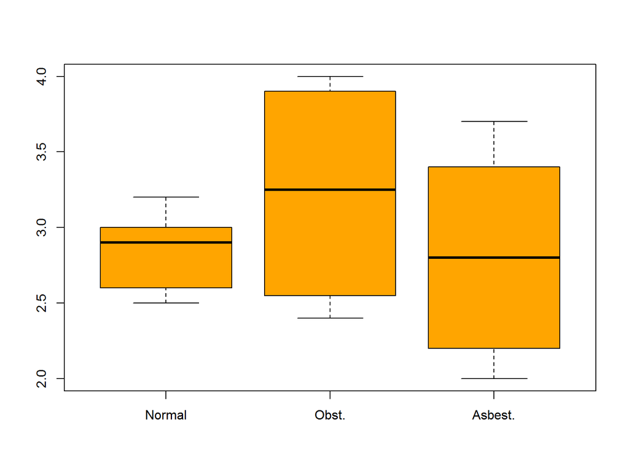

```r
# Exemple Kruskal-Wallis
taxa<-c(2.9,3,2.5,2.6,3.2,3.8,2.7,4,2.4,2.8,3.4,3.7,2.2,2)
fact<-factor(c(rep(1,5),rep(2,4),rep(3,5)),labels=c('Normal','Obst.','Asbest.'))
dades<-data.frame(fact,taxa)
# Descriptiva
boxplot(taxa~fact,dades,col='orange')
```

El calcul resumit de l’estadístic és

$K = \frac{12}{14 \cdot 15} (5(7.2-7.5)^2+4(9-7.5)^2+5(6.6-7.5)^2)=0.7714$

```r
# Test de Kruskal-Wallis
kruskal.test(taxa~fact,dades)
```

```
##
##  Kruskal-Wallis rank sum test
##
## data:  taxa by fact
## Kruskal-Wallis chi-squared = 0.7714, df = 2, p-value = 0.68
```

# Kruskal-Wallis com un ANOVA amb els rangs

Si apliquem el test ANOVA ordinari als rangs com a variable resposta en lloc de la variable original obtindriem

$F = \frac{\frac{K}{a-1}}{\frac{N-1-K}{N-a}}$

Per tant aplicar Kruskal-Wallis és equivalent a aplicar un ANOVA ordinari als rangs de les observacions.

```r
# Kruskal-Wallis com un ANOVA amb els rangs
dades$rang<-rank(dades$taxa)
anova(aov(rang~fact,dades))
```

```
## Analysis of Variance Table
##
## Response: rang
##           Df Sum Sq Mean Sq F value Pr(>F)
## fact       2   13.5   6.750   0.347 0.7143
## Residuals 11  214.0  19.454
```

```r
# F=(K/(a-1))/((N-1-K)/(N-a))  on K és l'estadístic de Kruskal-Wallis
K<-unname(kruskal.test(taxa~fact,dades)$statistic)
a<-nlevels(dades$fact)
N<-length(dades$fact)
F<-(K/(a-1))/((N-1-K)/(N-a))
F
```

```
## [1] 0.3469626
```

# Comparacions múltiples per Kruskal-Wallis

```r
# Comparacions múltiples
library(agricolae)
kruskal(dades$taxa,dades$fact,p.adj="bonferroni",console=T)
```

```
##
## Study: dades$taxa ~ dades$fact
## Kruskal-Wallis test's
## Ties or no Ties
##
## Value: 0.7714286
## degrees of freedom: 2
## Pvalue chisq  : 0.6799648
##
## dades$fact,  means of the ranks
##
##         dades.taxa r
## Asbest.        6.6 5
## Normal         7.2 5
## Obst.          9.0 4
##
## P value adjustment method: bonferroni
## t-Student: 2.820034
## Alpha    : 0.05
## Minimum difference changes for each comparison
##
## Means with the same letter are not significantly different
##
## Groups, Treatments and mean of the ranks
## a     Obst.       9
## a     Normal      7.2
## a     Asbest.     6.6
```

Una alternativa més lliberal és fer l’adjust dels p-valors per “fdr” en lloc de bonferroni.

Podeu ampliar en el següent enllaç els conceptes de [Comparacions múltiples (*Multiple Testing*)](https://en.wikipedia.org/wiki/Multiple_comparisons_problem)